# Belanger Data Prep

Dave Paunesku

September 19, 2014

# Goals

Prepare for analysis the data collected as part of Belanger’s Mindset Challenge experiment on Khan Academy. Specifically:

1. Aggregate the large datasets into more managable ones.
2. Preprocess key variables and perform time consuming merge operations.

# Data Integrity

## Duplicate Users

There are 245679 users in the users dataset and 245679 rows. So there are 0 duplicate users.

## Masteries Earned

Some users never attained mastery, but everyone in the mastery dataset was also in the users dataset.

```r
users <- unique(u$user)
pretty_table(table(m$user %in% users))
```

|  | V1 |
| --- | --- |
| TRUE | 8535677 |

```r
pretty_table(table(users %in% m$user))
```

|  | V1 |
| --- | --- |
| FALSE | 109694 |
| TRUE | 135985 |

## Problems Attempted

Some users never tried any problems, but everyone who attempted a problem was also in the users dataset.

```r
pretty_table(table(p$user %in% users))
```

|  | V1 |
| --- | --- |
| TRUE | 38565254 |

```r
pretty_table(table(users %in% p$user))
```

|  | V1 |
| --- | --- |
| FALSE | 59806 |
| TRUE | 185873 |

## Conditions Set

Everyone has a condition, and assignment to condition is approximately equal.

```r
pretty_table(table(is.na(u$control)))
```

|  | V1 |
| --- | --- |
| FALSE | 245679 |

```r
pretty_table(table(u$control))
```

|  | V1 |
| --- | --- |
| false | 122575 |
| true | 123104 |

# Data Processing

## Relabeling Variables

Let’s give the treatment condition and coach status nicer labels.

```r
u$condition <- ifelse(u$control,"Control","Treatment")
u$coached <- ifelse(u$coached,"Coached","Uncoached")
```

## Masteries

The following code blocks aggregate information about masteries to the level of day for each student and to the whole-student level. Mastery progress is demarked with an “outgoing_level”.

### Skill Change

Students can start at any particular level and level up or level down.

```r
# Recode mastery levels so they're in order for easy reading.
mastery_levels <- c("unstarted","practiced","mastery1","mastery2","mastery3")
m$incoming_level <- factor(m$incoming_level, levels=mastery_levels)
m$outgoing_level <- factor(m$outgoing_level, levels=mastery_levels)
pretty_table(table(m$incoming_level, m$outgoing_level))
```

|  | unstarted | practiced | mastery1 | mastery2 | mastery3 |
| --- | --- | --- | --- | --- | --- |
| unstarted | 0 | 2156429 | 365976 | 9742 | 408606 |
| practiced | 361296 | 0 | 1401750 | 76144 | 366153 |
| mastery1 | 30182 | 199062 | 0 | 1215676 | 306760 |
| mastery2 | 19824 | 79 | 136184 | 0 | 1313739 |
| mastery3 | 0 | 11797 | 0 | 155769 | 0 |

Since students can level up or level down, create a numerical value for change in skill level.

```r
m$skill_change <-
  match(m$outgoing_level,mastery_levels) -
  match(m$incoming_level,mastery_levels)
```

## Attained Level

Make variables corresponding to the attainment of a particular level of mastery. This will let us assess whether any treatment effects are driven by effects on participants getting their feet wet (practiced), starting to get it (mastery1), or deeply learning concepts (mastery3). I’ll only give you points for reaching a mastery level if you were leveling up.

```r
m$practiced <- m$outgoing_level %in% "practiced" &
  m$skill_change > 0
m$mastery1 <- m$outgoing_level %in% "mastery1" &
  m$skill_change > 0
m$mastery3 <- m$outgoing_level %in% "mastery3" &
  m$skill_change > 0
```

### md - The “mastery day” data frame

Make new variables corresponding to days so we can aggregate mastery changes to that level.

```r
to_date <- function(time) as.Date(as.POSIXct(time, origin="1970-01-01"))
u$participation_date  <- to_date(u$participation_time)
m$participation_date  <- to_date(m$participation_time)
m$mastery_date        <- to_date(m$time_done)

m$day <- as.numeric(difftime(m$mastery_date, m$participation_date, units="days" ))
```

Aggregate masteries to the day level in the md (mastery day) data frame.

```r
md <- group_by(m, user, day) %.%
  summarise( skill_change=sum(skill_change) ,
             practiced=sum(practiced) ,
             mastery3=sum(mastery3) ,
             mastery1=sum(mastery1)
             )
```

```r
days <- expand.grid( user=u$user, day=c(-30:30) )
days<- merge( days, u, by="user" )
md <- merge( days, md, by=c("user","day"), all.x=TRUE )
md$skill_change[is.na(md$skill_change)] <- 0
md$practiced[is.na(md$practiced)] <- 0
md$mastery1[is.na(md$mastery1)] <- 0
md$mastery3[is.na(md$mastery3)] <- 0
md$post <- ifelse(md$day >= 0,1,0)
```

### w - a “wide” format data frame

```r
# aggregate to the user pre/post level
ag <- group_by( md , user, post, coached, condition ) %.%
  summarise( skill_change=sum(skill_change) ,
             practiced=sum(practiced) ,
             mastery1=sum(mastery1),
             mastery3=sum(mastery3)
             )

# merge the pre and post data horizontally
outcomes <- c("skill_change","practiced","mastery1","mastery3")
w <- merge( ag[ag$post %in% 1, c("user",outcomes)],
    ag[ag$post %in% 0, c("user",outcomes,"coached","condition")] ,
    by="user",suffixes=c("","_pre"))
```

## Data Transformation

The primary outcomes have odd (difficult to model) distributions.

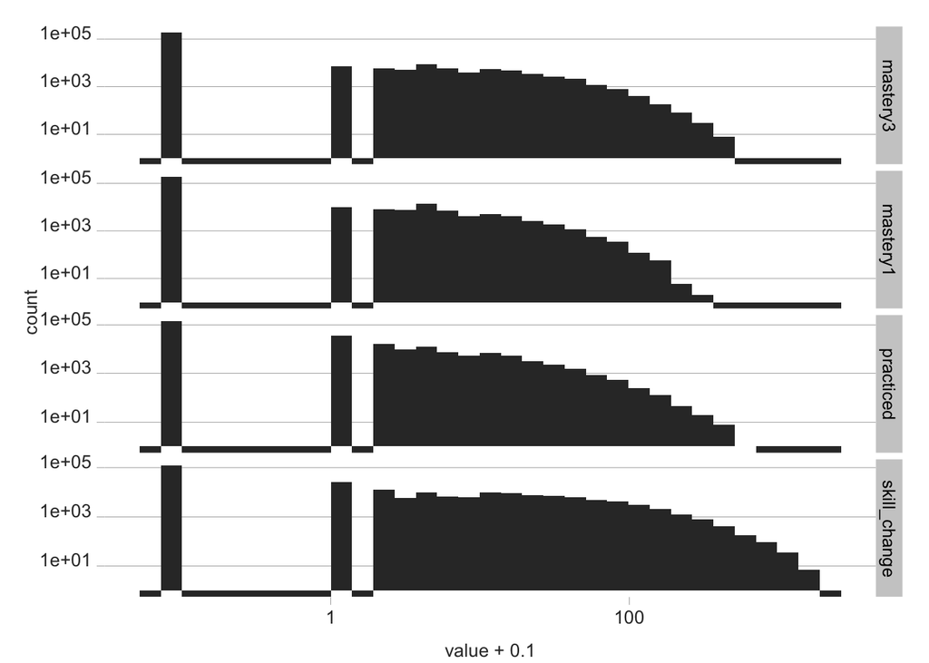

```r
primary_outcomes <- c("mastery3","mastery1","practiced","skill_change")

# melt the data for graphing
m <- melt( w[,c("user",primary_outcomes)] ,
           id.vars=c("user") )

# disributions of primary outcomes
ggplot( m, aes( value + .1 ) ) + ht +
  geom_histogram() +
  scale_x_log10() +
  scale_y_log10() +
  facet_grid( variable ~ . , scales="free")
```

### Log Outcomes

Create log versions of each outcome as well.

```r
w$mastery3_log  <- log_trans( w$mastery3 )
w$mastery1_log  <- log_trans( w$mastery1 )
w$practiced_log <- log_trans( w$practiced )
w$improved_log  <- log_trans( w$skill_change )

md$mastery3_log  <- log_trans( md$mastery3 )
md$mastery1_log  <- log_trans( md$mastery1 )
md$practiced_log <- log_trans( md$practiced )
md$improved_log  <- log_trans( md$skill_change )
```

### Binary Outcomes

Create binary versions of each outcome so we can use logistic regression to model them. That is, we assign each outcome a `TRUE` if the person made any progress on that outcome in the specified range of time.

```r
w$mastery3_bin  <- ifelse( w$mastery3 > 0, 1, 0)
w$mastery1_bin  <- ifelse( w$mastery1 > 0, 1, 0)
w$practiced_bin <- ifelse( w$practiced > 0, 1, 0)
w$improved_bin  <- ifelse( w$skill_change > 0, 1, 0)

md$mastery3_bin  <- ifelse( md$mastery3 > 0, 1, 0)
md$mastery1_bin  <- ifelse( md$mastery1 > 0, 1, 0)
md$practiced_bin <- ifelse( md$practiced > 0, 1, 0)
md$improved_bin  <- ifelse( md$skill_change > 0, 1, 0)
```

## Engagement

Use the problems dataset to determine:

- Number of problems attempted: `day_attempted` and `total_attempted`
- Number of problems correct: `day_correct` and `total_correct`
- Problem accuracy: `day_accuracy` and `total_accuracy`
- Unique hours on site: `day_active_hours` and `total_active_hours`

Note that `day` refers to day relative to `participation_time` (first exposure to intervention).

### pd - the “problem-day” data frame

```r
p$participation_date <- p$participation_time %>%
  as.POSIXct( . , origin="1970-01-01") %>%
  as.Date()

p$problem_date <- p$time_done %>%
  as.POSIXct( . , origin="1970-01-01") %>%
  as.Date()

p$day <- difftime(p$problem_date, p$participation_date, units="days" ) %>%
  as.numeric()

p$active_hour <- ( p$time_done / ( 60 * 60 ) ) %>%
  round()

# recode correct to calculate nicely
p$correct <- ifelse( p$correct %in% "true", 1, 0)

pd <- group_by( p, user, day, problem_date ) %.%
  summarise(
    day_attempted=length(correct),
    day_correct=sum(correct),
    day_accuracy=mean(correct, na.rm=T),
    day_active_hours=count_unique(active_hour)
    )

pd <- merge( days, pd, by=c("user","day"), all.x=TRUE )

# fill out missing values
pd$day_attempted[is.na(pd$day_attempted)] <- 0
pd$day_correct[is.na(pd$day_correct)] <- 0
```

### d - A merge of problem days (pd) into mastery days (md)

```r
pd_vars <- c( "user","day","day_attempted",
              "day_accuracy","day_correct","day_active_hours")
d <- merge( md, pd[,pd_vars], by=c("user","day") )
```

### w - Append student-level problems & time to wide dataset

```r
p$post <- ifelse(p$day >=0, 1,0)
pw <- group_by( p[p$day > -31 & p$day < 31,], user, post ) %.%
  summarise(
    total_attempted=length(correct),
    total_correct=sum(correct),
    total_accuracy=mean(correct, na.rm=T),
    total_active_hours=count_unique(active_hour)
    )

vars <- c("user","total_attempted","total_correct","total_active_hours")
temp <- merge( w ,
             pw[pw$post == 1,vars] ,
             by="user",
             all.x=TRUE
             )

temp <- merge( temp ,
             pw[pw$post == 0,vars] ,
             by="user",
             suffixes=c("","_pre"),
             all.x=TRUE
             )

# set missing values to 0
vars <- c("total_attempted","total_attempted_pre",
           "total_correct","total_correct_pre",
          "total_active_hours","total_active_hours_pre")
temp[,vars][is.na(temp[,vars])] <- 0

w <- temp
rm(temp)
```

# User Categorization

## Classify Newbies

```r
w$newbie  <- ifelse( w$skill_change_pre > 0, "Veteran", "Newbie")
w$newbie_problems <- ifelse( w$total_attempted_pre > 0, "Veteran", "Newbie")
w$newbie_mastery3  <- ifelse( w$mastery3_pre > 0, "Veteran", "Newbie")
```

## Incorporate User-Level Variables into Daily Data

These will be used as moderators.

```r
moderator_vars <- names(w)[grep("_pre|newbie",names(w))]
d <- merge( d, w[,c("user",moderator_vars)], by="user" )
```

# Save Processed Data

```r
setwd("~/Dropbox/studies/ka belanger")
write.csv(d,"daily.csv",row.names=FALSE)
write.csv(w,"wide.csv",row.names=FALSE)
```